# Machine Learning Assignment

preethi

11/21/2019

## Description of the dataset

Using devices such as Jawbone Up, Nike FuelBand, and Fitbit it is now possible to collect a large amount of data about personal activity relatively inexpensively. One thing that people regularly do is quantify how much of a particular activity they do, but they rarely quantify how well they do it. In this project, our goal will be to use data from accelerometers on the belt, forearm, arm, and dumbell of 6 participants. They were asked to perform barbell lifts correctly and incorrectly in 5 different ways. More information is available from the [website](http://web.archive.org/web/20161224072740/http:/groupware.les.inf.puc-rio.br/har).

The goal of this project is to determine the manner in which they did the exercise. This is the “Classe” Variable in the training set.

What is the classe variable

Class A - exactly according to the specification Class B - throwing the elbows to the front Class C - lifting the dumbbell only halfway Class D - lowering the dumbbell only halfway Class E - throwing the hips to the front

We have already been given a training and test set. First we lad the required the packages and the set the seed for uniformity

```r
library(caret)
library(dplyr)
library(tidyr)
library(randomForest)
library(rpart)
library(rpart.plot)
set.seed(2)
```

Then we download the training and test file and read them appropriately (specifically the na’s)

```r
if (!file.exists("pml-training.csv")){    download.file("https://d396qusza40orc.cloudfront.net/predmachlearn/pml-training.csv",destfile = "./pml-training.csv", quiet = TRUE)}

if (!file.exists("pml-testing.csv")){
download.file("https://d396qusza40orc.cloudfront.net/predmachlearn/pml-testing.csv",destfile = "./pml-testing.csv", quiet = TRUE)}

training_data <- read.csv("pml-training.csv", header = TRUE, na.strings = c("NA","#DIV/0!",""))
test_data <- read.csv("pml-testing.csv", header = TRUE, na.strings = c("NA","#DIV/0!",""))

dim(training_data)
```

```
## [1] 19622   160
```

```r
dim(test_data)
```

```
## [1]  20 160
```

We now have our training data.Looking at it, there are some columns that wont be used toward the prediction. we can remove those in both training and testing data.

```r
trains <- subset(training_data,select = -c(1:7))

test <- subset(test_data,select = -c(1:7))

dim(trains)
```

```
## [1] 19622   153
```

```r
dim(test)
```

```
## [1]  20 153
```

The training data is then partitioned furrther into a validation and training set.

```r
trainindex <- createDataPartition (trains$classe, p = 0.6, list = FALSE)

pml_train <- trains[trainindex,]
pml_validate <- trains[-trainindex,]

dim(pml_train)
```

```
## [1] 11776   153
```

```r
dim(pml_validate)
```

```
## [1] 7846  153
```

First we clean the training data set of columns that have too many Na’s and then check to see if there are columns with near 0 variances.

```r
training <- pml_train %>%
  purrr::discard(~sum(is.na(.x))/length(.x)* 100 >= 90)

dim(training)
```

```
## [1] 11776    53
```

```r
nzv <- nearZeroVar(training)

nzv
```

```
## integer(0)
```

Since there are no near 0 variances after the dataset is cleared of na columns. We can go ahead and clear the validation and test sets the same way.

```r
Cleannames <- colnames(training)
Cleannames2 <- colnames(training[,-53])


pml_validate <- pml_validate[Cleannames]

test <- test[Cleannames2]

dim(pml_validate)
```

```
## [1] 7846   53
```

```r
dim(test)
```

```
## [1] 20 52
```

First we fit a desicion tree model with rpart and plot it.

```r
desc_tree <- rpart(classe~., data = training, method = "class")

prediction_desc <- predict(desc_tree, data = training, type = "class")

confusionMatrix(prediction_desc,training$classe)
```

```
## Confusion Matrix and Statistics
##
##           Reference
## Prediction    A    B    C    D    E
##          A 2976  443   31  174   90
##          B   87 1346  254   91  226
##          C   96  248 1576  300  261
##          D  140  181  144 1288  204
##          E   49   61   49   77 1384
##
## Overall Statistics
##
##                Accuracy : 0.7278
##                  95% CI : (0.7196, 0.7358)
##     No Information Rate : 0.2843
##     P-Value [Acc > NIR] : < 2.2e-16
##
##                   Kappa : 0.6546
##
##  Mcnemar's Test P-Value : < 2.2e-16
##
## Statistics by Class:
##
##                      Class: A Class: B Class: C Class: D Class: E
## Sensitivity            0.8889   0.5906   0.7673   0.6674   0.6393
## Specificity            0.9124   0.9307   0.9069   0.9321   0.9754
## Pos Pred Value         0.8013   0.6717   0.6352   0.6582   0.8543
## Neg Pred Value         0.9539   0.9045   0.9486   0.9346   0.9231
## Prevalence             0.2843   0.1935   0.1744   0.1639   0.1838
## Detection Rate         0.2527   0.1143   0.1338   0.1094   0.1175
## Detection Prevalence   0.3154   0.1702   0.2107   0.1662   0.1376
## Balanced Accuracy      0.9007   0.7607   0.8371   0.7997   0.8074
```

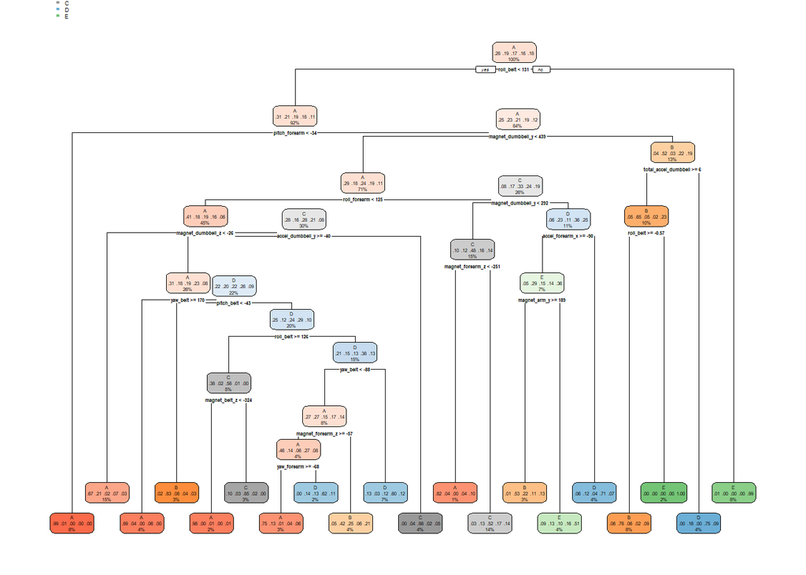

```r
rpart.plot(desc_tree)
```

Now we can use a Random Forest plot on the training data using Classe as the outcome and everything else as the predictor.

```r
forest_model <- randomForest(classe~.,data = training, na.action=na.omit, method = "class")
##predicting on the validation data set
prediction <- predict(forest_model,pml_validate, type = "class")
##confusion matrix with the same.
confusionMatrix(prediction, pml_validate$classe)
```

```
## Confusion Matrix and Statistics
##
##           Reference
## Prediction    A    B    C    D    E
##          A 2230   10    0    0    0
##          B    2 1508   19    0    0
##          C    0    0 1346   13    0
##          D    0    0    3 1272    3
##          E    0    0    0    1 1439
##
## Overall Statistics
##
##                Accuracy : 0.9935
##                  95% CI : (0.9915, 0.9952)
##     No Information Rate : 0.2845
##     P-Value [Acc > NIR] : < 2.2e-16
##
##                   Kappa : 0.9918
##
##  Mcnemar's Test P-Value : NA
##
## Statistics by Class:
##
##                      Class: A Class: B Class: C Class: D Class: E
## Sensitivity            0.9991   0.9934   0.9839   0.9891   0.9979
## Specificity            0.9982   0.9967   0.9980   0.9991   0.9998
## Pos Pred Value         0.9955   0.9863   0.9904   0.9953   0.9993
## Neg Pred Value         0.9996   0.9984   0.9966   0.9979   0.9995
## Prevalence             0.2845   0.1935   0.1744   0.1639   0.1838
## Detection Rate         0.2842   0.1922   0.1716   0.1621   0.1834
## Detection Prevalence   0.2855   0.1949   0.1732   0.1629   0.1835
## Balanced Accuracy      0.9987   0.9950   0.9910   0.9941   0.9989
```

## Conclusion

```r
forest_model$importance
```

```
##                      MeanDecreaseGini
## roll_belt                   740.23611
## pitch_belt                  420.66462
## yaw_belt                    542.38912
## total_accel_belt            136.95505
## gyros_belt_x                 60.67067
## gyros_belt_y                 72.66345
## gyros_belt_z                189.02644
## accel_belt_x                 72.11499
## accel_belt_y                 80.41811
## accel_belt_z                241.06516
## magnet_belt_x               145.85669
## magnet_belt_y               238.98521
## magnet_belt_z               227.29123
## roll_arm                    178.36662
## pitch_arm                   100.13126
## yaw_arm                     144.08626
## total_accel_arm              61.98249
## gyros_arm_x                  76.71189
## gyros_arm_y                  78.75831
## gyros_arm_z                  39.82521
## accel_arm_x                 139.60323
## accel_arm_y                  92.65449
## accel_arm_z                  71.40787
## magnet_arm_x                143.05937
## magnet_arm_y                122.54544
## magnet_arm_z                112.37915
## roll_dumbbell               261.41199
## pitch_dumbbell              107.11975
## yaw_dumbbell                158.30380
## total_accel_dumbbell        159.78099
## gyros_dumbbell_x             75.30264
## gyros_dumbbell_y            136.41253
## gyros_dumbbell_z             45.62413
## accel_dumbbell_x            148.96298
## accel_dumbbell_y            284.41959
## accel_dumbbell_z            200.22844
## magnet_dumbbell_x           307.43345
## magnet_dumbbell_y           429.65783
## magnet_dumbbell_z           457.00835
## roll_forearm                360.55323
## pitch_forearm               464.84379
## yaw_forearm                  93.69010
## total_accel_forearm          69.03790
## gyros_forearm_x              45.85716
## gyros_forearm_y              72.82269
## gyros_forearm_z              48.84421
## accel_forearm_x             192.02960
## accel_forearm_y              82.00047
## accel_forearm_z             144.72689
## magnet_forearm_x            129.92569
## magnet_forearm_y            131.93520
## magnet_forearm_z            171.77639
```

```r
forest_model$err.rate[500,1]
```

```
##         OOB
## 0.007302989
```